# 30-Day Mortality Condition of Myocardia Infarction Patients Admitted to All Seven Care Units

Yu Chen 305266880

# Introduction

This report analyzes the electronic health record (EHR) data MIMIC-III. By working with PostgreSQL database, data visualization, and commonly used analytical methods such as logistic regression and neural network, I try to analyze 30-day mortality condition of myocardia infarction patients admitted to all seven care units. It shows a better picture of hospital conditions and can have a positive impact on decision making.

# Data Preparation

Load database libraries and the tidyverse frontend:

```r
library(DBI)
library(RPostgreSQL)
library(tidyverse)
library(lubridate)
```

Credentials for using PostgreSQL database. We are going to use username `postgres` with password `postgres` to access the `mimic` database in the schemee `mimiciii`.

```r
# Load configuration settings
dbdriver <- 'PostgreSQL'
#host  <- '127.0.0.1'
#port  <- '5432'
user  <- 'postgres'
password <- 'postgres'
dbname <- 'mimic'
schema <- 'mimiciii'
# Connect to the database using the configuration settings
con <- dbConnect(RPostgreSQL::PostgreSQL(),
                 dbname = dbname,
                 #host = host,
                 #port = port,
                 user = user,
                 password = password)
# Set the default schema
dbExecute(con, paste("SET search_path TO ", schema, sep=" "))
```

```
## [1] 0
```

```r
con
```

```
## <PostgreSQLConnection>
```

In this section, we demo how to create a cohort of patients admitted into CCU, CSRU, MICU, NICU, NWARD, SICU and TSICU and were diagnosed with Myocardia Infarction.

First we create a (query) table of patients who were directly admitted into CCU, CSRU, MICU, NICU, NWARD, SICU and TSICU.

```r
tbl(con, "transfers") %>%
  select(subject_id, hadm_id, prev_careunit, curr_careunit) %>%
  filter(is.na(prev_careunit) & curr_careunit == "CCU") %>%
  select(subject_id, hadm_id) %>%
  distinct() %>%
  print() -> ccu_admissions
```

```
## # Source:   lazy query [?? x 2]
## # Database: postgres 11.0.7 [postgres@/var/run/postgresql:5432/mimic]
##    subject_id hadm_id
##         <int>   <int>
##  1      42525  142743
##  2      23028  190183
##  3      24357  111518
##  4      23872  120477
##  5       9768  128541
##  6      23474  128369
##  7      30292  113876
##  8      19848  167716
##  9      12138  131429
## 10      10616  122738
## # … with more rows
```

```r
tbl(con, "transfers") %>%
  select(subject_id, hadm_id, prev_careunit, curr_careunit) %>%
  filter(is.na(prev_careunit) & curr_careunit == "CSRU") %>%
  select(subject_id, hadm_id) %>%
  distinct() %>%
  print() -> csru_admissions
```

```
## # Source:   lazy query [?? x 2]
## # Database: postgres 11.0.7 [postgres@/var/run/postgresql:5432/mimic]
##    subject_id hadm_id
##         <int>   <int>
##  1       3704  179297
##  2      21614  101793
##  3      18694  112069
##  4       3609  129368
##  5       1674  177296
##  6      93307  152763
##  7      12679  154376
##  8       4969  114635
##  9      81923  101866
## 10      51014  116656
## # … with more rows
```

```r
tbl(con, "transfers") %>%
  select(subject_id, hadm_id, prev_careunit, curr_careunit) %>%
  filter(is.na(prev_careunit) & curr_careunit == "MICU") %>%
  select(subject_id, hadm_id) %>%
  distinct() %>%
  print() -> micu_admissions
```

```
## # Source:   lazy query [?? x 2]
## # Database: postgres 11.0.7 [postgres@/var/run/postgresql:5432/mimic]
##    subject_id hadm_id
##         <int>   <int>
##  1        711  120522
##  2      20863  195453
##  3      97716  178708
##  4      60131  190090
##  5      19705  155006
##  6      11342  165519
##  7      74147  149842
##  8      18958  122966
##  9       7681  175048
## 10      65665  170768
## # … with more rows
```

```r
tbl(con, "transfers") %>%
  select(subject_id, hadm_id, prev_careunit, curr_careunit) %>%
  filter(is.na(prev_careunit) & curr_careunit == "NICU") %>%
  select(subject_id, hadm_id) %>%
  distinct() %>%
  print() -> nicu_admissions
```

```
## # Source:   lazy query [?? x 2]
## # Database: postgres 11.0.7 [postgres@/var/run/postgresql:5432/mimic]
##    subject_id hadm_id
##         <int>   <int>
##  1      21841  149504
##  2      28418  151945
##  3       6819  100684
##  4       2663  160263
##  5      20233  106503
##  6      16983  189645
##  7      16648  182973
##  8      11528  181867
##  9      30619  165770
## 10       8854  125116
## # … with more rows
```

```r
tbl(con, "transfers") %>%
  select(subject_id, hadm_id, prev_careunit, curr_careunit) %>%
  filter(is.na(prev_careunit) & curr_careunit == "NWARD") %>%
  select(subject_id, hadm_id) %>%
  distinct() %>%
  print() -> nward_admissions
```

```
## # Source:   lazy query [?? x 2]
## # Database: postgres 11.0.7 [postgres@/var/run/postgresql:5432/mimic]
##    subject_id hadm_id
##         <int>   <int>
##  1      31089  110616
##  2      20772  137635
##  3      14368  130081
##  4      22689  192509
##  5      32101  160758
##  6      13155  195214
##  7       3233  109406
##  8       7211  101485
##  9      22828  123853
## 10       3188  133560
## # … with more rows
```

```r
tbl(con, "transfers") %>%
  select(subject_id, hadm_id, prev_careunit, curr_careunit) %>%
  filter(is.na(prev_careunit) & curr_careunit == "SICU") %>%
  select(subject_id, hadm_id) %>%
  distinct() %>%
  print() -> sicu_admissions
```

```
## # Source:   lazy query [?? x 2]
## # Database: postgres 11.0.7 [postgres@/var/run/postgresql:5432/mimic]
##    subject_id hadm_id
##         <int>   <int>
##  1      68300  128859
##  2      25270  120136
##  3      86209  151730
##  4       1956  115722
##  5      97660  101056
##  6      82633  113066
##  7      61569  114157
##  8      23463  131647
##  9      10139  142190
## 10      83892  121919
## # … with more rows
```

```r
tbl(con, "transfers") %>%
  select(subject_id, hadm_id, prev_careunit, curr_careunit) %>%
  filter(is.na(prev_careunit) & curr_careunit == "TSICU") %>%
  select(subject_id, hadm_id) %>%
  distinct() %>%
  print() -> tsicu_admissions
```

```
## # Source:   lazy query [?? x 2]
## # Database: postgres 11.0.7 [postgres@/var/run/postgresql:5432/mimic]
##    subject_id hadm_id
##         <int>   <int>
##  1      23028  190183
##  2       9239  108694
##  3      14415  170014
##  4      84627  159498
##  5      94530  179516
##  6      22769  121431
##  7      74346  142253
##  8       8808  181908
##  9      24168  124185
## 10      32551  190198
## # … with more rows
```

Now we want to restrict to Myocardia Infarction Patients. To find all possible ICD-9 codes related to heart attack, we search for string `myocardial infarction` in the `long_title` of table `d_icd_diagnoses`:

```r
mi_codes <- tbl(con, "d_icd_diagnoses") %>%
  filter(str_detect(tolower(long_title), "myocardial infarction"))
```

```r
tbl(con, "diagnoses_icd") %>%
  semi_join(mi_codes, by = "icd9_code") %>%
  print() -> mi_admissions
```

```
## # Source:   lazy query [?? x 5]
## # Database: postgres 11.0.7 [postgres@/var/run/postgresql:5432/mimic]
##    row_id subject_id hadm_id seq_num icd9_code
##     <int>      <int>   <int>   <int> <chr>
##  1 175785      15805  188616       1 41000
##  2 281839      25208  167918       7 41000
##  3    594         73  194730       1 41001
##  4   6395        543  115307       1 41001
##  5   6630        571  193189       1 41001
##  6  11015        947  122379       1 41001
##  7  12916       1114  164691       2 41001
##  8  14945       1317  198886       1 41001
##  9  18340       1626  117062       1 41001
## 10  30343       2700  100335       1 41001
## # … with more rows
```

MI may not be listed as the principal diagnosis; as explained in [the documentation for the `patients` table](https://mimic.physionet.org/mimictables/diagnoses_icd/), the `seq_num` field is a priority ranking for the diagnoses generated at the end of stay. In order to focus on patients for whom MI was central to their hospitalization, we will include records with MI in any of the first five diagnosis positions, according to the `seq_num` field. To avoid duplicate admissions, we use `group_by()` and `top_n()` to limit the query to the first MI diagnosis for each admission.

```r
mi_admissions <- mi_admissions %>%
  filter(seq_num <= 5) %>%
  group_by(subject_id, hadm_id) %>%
  filter(min_rank(seq_num) <= 1) %>%
  ungroup() %>%
  select(subject_id, hadm_id, icd9_code, seq_num)
```

Now we `inner_join` the table of admissions to all the unit cares and the table of admissions that include MI diagnosis.

```r
study_admissions_ccu <- ccu_admissions %>%
  inner_join(mi_admissions, by = c("subject_id", "hadm_id")) %>%
  print()
```

```
## # Source:   lazy query [?? x 4]
## # Database: postgres 11.0.7 [postgres@/var/run/postgresql:5432/mimic]
##    subject_id hadm_id icd9_code seq_num
##         <int>   <int> <chr>       <int>
##  1         24  161859 41041           1
##  2         42  119203 412             4
##  3         53  155385 41021           1
##  4         73  194730 41001           1
##  5        111  192123 41081           5
##  6        123  195632 41011           1
##  7        149  154869 41011           1
##  8        154  111735 41041           1
##  9        158  169433 412             4
## 10        160  161672 41041           1
## # … with more rows
```

```r
study_admissions_csru <- csru_admissions %>%
  inner_join(mi_admissions, by = c("subject_id", "hadm_id")) %>%
  print()
```

```
## # Source:   lazy query [?? x 4]
## # Database: postgres 11.0.7 [postgres@/var/run/postgresql:5432/mimic]
##    subject_id hadm_id icd9_code seq_num
##         <int>   <int> <chr>       <int>
##  1         28  162569 412             4
##  2         79  181542 41011           1
##  3        108  123552 412             5
##  4        223  105694 41021           2
##  5        525  128280 41041           1
##  6        583  193132 41041           2
##  7        625  145523 41011           3
##  8        947  141508 41011           1
##  9        953  175948 41042           5
## 10        995  127558 412             3
## # … with more rows
```

```r
study_admissions_micu <- micu_admissions %>%
  inner_join(mi_admissions, by = c("subject_id", "hadm_id")) %>%
  print()
```

```
## # Source:   lazy query [?? x 4]
## # Database: postgres 11.0.7 [postgres@/var/run/postgresql:5432/mimic]
##    subject_id hadm_id icd9_code seq_num
##         <int>   <int> <chr>       <int>
##  1        154  102354 41081           1
##  2        223  105694 41021           2
##  3        302  191028 41011           1
##  4        561  105399 412             4
##  5        876  158204 41031           2
##  6        906  113399 41011           1
##  7        952  165175 412             5
##  8        952  197486 412             5
##  9       1119  172919 41091           2
## 10       1120  149095 41091           1
## # … with more rows
```

```r
study_admissions_nicu <- nicu_admissions %>%
  inner_join(mi_admissions, by = c("subject_id", "hadm_id")) %>%
  print()
```

```
## # Source:   lazy query [?? x 4]
## # Database: postgres 11.0.7 [postgres@/var/run/postgresql:5432/mimic]
```

```r
study_admissions_nward <- nward_admissions %>%
  inner_join(mi_admissions, by = c("subject_id", "hadm_id")) %>%
  print()
```

```
## # Source:   lazy query [?? x 4]
## # Database: postgres 11.0.7 [postgres@/var/run/postgresql:5432/mimic]
```

```r
study_admissions_sicu <- sicu_admissions %>%
  inner_join(mi_admissions, by = c("subject_id", "hadm_id")) %>%
  print()
```

```
## # Source:   lazy query [?? x 4]
## # Database: postgres 11.0.7 [postgres@/var/run/postgresql:5432/mimic]
##    subject_id hadm_id icd9_code seq_num
##         <int>   <int> <chr>       <int>
##  1        177  196896 41091           2
##  2        423  128697 41091           2
##  3        434  175451 41091           3
##  4        755  127323 412             5
##  5        780  140935 41041           1
##  6        950  101579 41091           5
##  7       1626  117062 41001           1
##  8       2149  128303 412             5
##  9       2600  124863 41091           5
## 10       3570  173078 41091           5
## # … with more rows
```

```r
study_admissions_tsicu <- tsicu_admissions %>%
  inner_join(mi_admissions, by = c("subject_id", "hadm_id")) %>%
  print()
```

```
## # Source:   lazy query [?? x 4]
## # Database: postgres 11.0.7 [postgres@/var/run/postgresql:5432/mimic]
##    subject_id hadm_id icd9_code seq_num
##         <int>   <int> <chr>       <int>
##  1        561  105399 412             4
##  2       1822  156361 41091           5
##  3       2129  154842 41091           2
##  4       4609  107158 41091           5
##  5       4698  111851 41091           4
##  6       4950  109626 41091           4
##  7       5532  164052 41091           5
##  8       6092  103191 41091           3
##  9       6362  110667 41091           1
## 10       7495  160504 41021           4
## # … with more rows
```

Now we create a logical variable indicating the MI is the principal diagonosis or not (according to `seq_num`).

```r
study_admissions_ccu <- study_admissions_ccu %>%
  mutate(principal_dx = seq_num == 1) %>%
  select(-seq_num) %>%
  print()
```

```
## # Source:   lazy query [?? x 4]
## # Database: postgres 11.0.7 [postgres@/var/run/postgresql:5432/mimic]
##    subject_id hadm_id icd9_code principal_dx
##         <int>   <int> <chr>     <lgl>
##  1         24  161859 41041     TRUE
##  2         42  119203 412       FALSE
##  3         53  155385 41021     TRUE
##  4         73  194730 41001     TRUE
##  5        111  192123 41081     FALSE
##  6        123  195632 41011     TRUE
##  7        149  154869 41011     TRUE
##  8        154  111735 41041     TRUE
##  9        158  169433 412       FALSE
## 10        160  161672 41041     TRUE
## # … with more rows
```

```r
study_admissions_csru <- study_admissions_csru %>%
  mutate(principal_dx = seq_num == 1) %>%
  select(-seq_num) %>%
  print()
```

```
## # Source:   lazy query [?? x 4]
## # Database: postgres 11.0.7 [postgres@/var/run/postgresql:5432/mimic]
##    subject_id hadm_id icd9_code principal_dx
##         <int>   <int> <chr>     <lgl>
##  1         28  162569 412       FALSE
##  2         79  181542 41011     TRUE
##  3        108  123552 412       FALSE
##  4        223  105694 41021     FALSE
##  5        525  128280 41041     TRUE
##  6        583  193132 41041     FALSE
##  7        625  145523 41011     FALSE
##  8        947  141508 41011     TRUE
##  9        953  175948 41042     FALSE
## 10        995  127558 412       FALSE
## # … with more rows
```

```r
study_admissions_micu <- study_admissions_micu %>%
  mutate(principal_dx = seq_num == 1) %>%
  select(-seq_num) %>%
  print()
```

```
## # Source:   lazy query [?? x 4]
## # Database: postgres 11.0.7 [postgres@/var/run/postgresql:5432/mimic]
##    subject_id hadm_id icd9_code principal_dx
##         <int>   <int> <chr>     <lgl>
##  1        154  102354 41081     TRUE
##  2        223  105694 41021     FALSE
##  3        302  191028 41011     TRUE
##  4        561  105399 412       FALSE
##  5        876  158204 41031     FALSE
##  6        906  113399 41011     TRUE
##  7        952  165175 412       FALSE
##  8        952  197486 412       FALSE
##  9       1119  172919 41091     FALSE
## 10       1120  149095 41091     TRUE
## # … with more rows
```

```r
study_admissions_sicu <- study_admissions_sicu %>%
  mutate(principal_dx = seq_num == 1) %>%
  select(-seq_num) %>%
  print()
```

```
## # Source:   lazy query [?? x 4]
## # Database: postgres 11.0.7 [postgres@/var/run/postgresql:5432/mimic]
##    subject_id hadm_id icd9_code principal_dx
##         <int>   <int> <chr>     <lgl>
##  1        177  196896 41091     FALSE
##  2        423  128697 41091     FALSE
##  3        434  175451 41091     FALSE
##  4        755  127323 412       FALSE
##  5        780  140935 41041     TRUE
##  6        950  101579 41091     FALSE
##  7       1626  117062 41001     TRUE
##  8       2149  128303 412       FALSE
##  9       2600  124863 41091     FALSE
## 10       3570  173078 41091     FALSE
## # … with more rows
```

```r
study_admissions_tsicu <- study_admissions_tsicu %>%
  mutate(principal_dx = seq_num == 1) %>%
  select(-seq_num) %>%
  print()
```

```
## # Source:   lazy query [?? x 4]
## # Database: postgres 11.0.7 [postgres@/var/run/postgresql:5432/mimic]
##    subject_id hadm_id icd9_code principal_dx
##         <int>   <int> <chr>     <lgl>
##  1        561  105399 412       FALSE
##  2       1822  156361 41091     FALSE
##  3       2129  154842 41091     FALSE
##  4       4609  107158 41091     FALSE
##  5       4698  111851 41091     FALSE
##  6       4950  109626 41091     FALSE
##  7       5532  164052 41091     FALSE
##  8       6092  103191 41091     FALSE
##  9       6362  110667 41091     TRUE
## 10       7495  160504 41021     FALSE
## # … with more rows
```

We want to add information about the severity of patients’ ailments. The `drgcodes` table contains, for `DRG` codes from the All Payers Registry (APR), severity and mortality indicators. We pull the drug severity information and right-join it to our query tables.

```r
tbl(con, "drgcodes") %>%
  filter(str_detect(drg_type, "APR")) %>%
  select(subject_id, hadm_id, drg_severity) %>%
  right_join(study_admissions_ccu, by = c("subject_id", "hadm_id")) %>%
  mutate(drg_severity = ifelse(is.na(drg_severity), 1, drg_severity)) %>%
  print() -> study_admissions_ccu
```

```
## # Source:   lazy query [?? x 5]
## # Database: postgres 11.0.7 [postgres@/var/run/postgresql:5432/mimic]
##    subject_id hadm_id drg_severity icd9_code principal_dx
##         <int>   <int>        <dbl> <chr>     <lgl>
##  1         24  161859            1 41041     TRUE
##  2         42  119203            1 412       FALSE
##  3         53  155385            1 41021     TRUE
##  4         73  194730            1 41001     TRUE
##  5        111  192123            4 41081     FALSE
##  6        123  195632            1 41011     TRUE
##  7        149  154869            1 41011     TRUE
##  8        154  111735            1 41041     TRUE
##  9        158  169433            1 412       FALSE
## 10        160  161672            1 41041     TRUE
## # … with more rows
```

```r
study_admissions_csru <- tbl(con, "drgcodes") %>%
  filter(str_detect(drg_type, "APR")) %>%
  select(subject_id, hadm_id, drg_severity) %>%
  right_join(study_admissions_csru, by = c("subject_id", "hadm_id")) %>%
  mutate(drg_severity = ifelse(is.na(drg_severity), 1, drg_severity)) %>%
  print() -> study_admissions_csru
```

```
## # Source:   lazy query [?? x 5]
## # Database: postgres 11.0.7 [postgres@/var/run/postgresql:5432/mimic]
##    subject_id hadm_id drg_severity icd9_code principal_dx
##         <int>   <int>        <dbl> <chr>     <lgl>
##  1         28  162569            1 412       FALSE
##  2         79  181542            1 41011     TRUE
##  3        108  123552            1 412       FALSE
##  4        223  105694            4 41021     FALSE
##  5        525  128280            1 41041     TRUE
##  6        583  193132            3 41041     FALSE
##  7        625  145523            1 41011     FALSE
##  8        947  141508            1 41011     TRUE
##  9        953  175948            3 41042     FALSE
## 10        995  127558            2 412       FALSE
## # … with more rows
```

```r
study_admissions_micu <- tbl(con, "drgcodes") %>%
  filter(str_detect(drg_type, "APR")) %>%
  select(subject_id, hadm_id, drg_severity) %>%
  right_join(study_admissions_micu, by = c("subject_id", "hadm_id")) %>%
  mutate(drg_severity = ifelse(is.na(drg_severity), 1, drg_severity)) %>%
  print() -> study_admissions_micu
```

```
## # Source:   lazy query [?? x 5]
## # Database: postgres 11.0.7 [postgres@/var/run/postgresql:5432/mimic]
##    subject_id hadm_id drg_severity icd9_code principal_dx
##         <int>   <int>        <dbl> <chr>     <lgl>
##  1        154  102354            1 41081     TRUE
##  2        154  102354            1 41081     TRUE
##  3        223  105694            4 41021     FALSE
##  4        302  191028            1 41011     TRUE
##  5        561  105399            1 412       FALSE
##  6        876  158204            1 41031     FALSE
##  7        906  113399            1 41011     TRUE
##  8        952  165175            1 412       FALSE
##  9        952  197486            1 412       FALSE
## 10       1119  172919            1 41091     FALSE
## # … with more rows
```

```r
study_admissions_sicu <- tbl(con, "drgcodes") %>%
  filter(str_detect(drg_type, "APR")) %>%
  select(subject_id, hadm_id, drg_severity) %>%
  right_join(study_admissions_sicu, by = c("subject_id", "hadm_id")) %>%
  mutate(drg_severity = ifelse(is.na(drg_severity), 1, drg_severity)) %>%
  print() -> study_admissions_sicu
```

```
## # Source:   lazy query [?? x 5]
## # Database: postgres 11.0.7 [postgres@/var/run/postgresql:5432/mimic]
##    subject_id hadm_id drg_severity icd9_code principal_dx
##         <int>   <int>        <dbl> <chr>     <lgl>
##  1        177  196896            1 41091     FALSE
##  2        423  128697            3 41091     FALSE
##  3        434  175451            1 41091     FALSE
##  4        755  127323            1 412       FALSE
##  5        780  140935            1 41041     TRUE
##  6        950  101579            1 41091     FALSE
##  7       1626  117062            1 41001     TRUE
##  8       2149  128303            1 412       FALSE
##  9       2600  124863            1 41091     FALSE
## 10       3570  173078            1 41091     FALSE
## # … with more rows
```

```r
study_admissions_tsicu <- tbl(con, "drgcodes") %>%
  filter(str_detect(drg_type, "APR")) %>%
  select(subject_id, hadm_id, drg_severity) %>%
  right_join(study_admissions_tsicu, by = c("subject_id", "hadm_id")) %>%
  mutate(drg_severity = ifelse(is.na(drg_severity), 1, drg_severity)) %>%
  print() -> study_admissions_tsicu
```

```
## # Source:   lazy query [?? x 5]
## # Database: postgres 11.0.7 [postgres@/var/run/postgresql:5432/mimic]
##    subject_id hadm_id drg_severity icd9_code principal_dx
##         <int>   <int>        <dbl> <chr>     <lgl>
##  1        561  105399            1 412       FALSE
##  2       1822  156361            1 41091     FALSE
##  3       2129  154842            1 41091     FALSE
##  4       4609  107158            1 41091     FALSE
##  5       4698  111851            1 41091     FALSE
##  6       4950  109626            1 41091     FALSE
##  7       5532  164052            4 41091     FALSE
##  8       6092  103191            1 41091     FALSE
##  9       6362  110667            4 41091     TRUE
## 10       7495  160504            4 41021     FALSE
## # … with more rows
```

Pull the admission time `admittime`, discharge time `dischtime`, date of birth `dob`, and date of death `dod`. We are interested in the mortaility rate 30 days after discharge. So we only keep patients who didn’t die in hospital.

```r
study_admissions_ccu %>%
  left_join(
    select(tbl(con, "admissions"),
           subject_id, hadm_id, admittime, dischtime, hospital_expire_flag
    ), by = c("subject_id", "hadm_id")
  ) %>%
  filter(hospital_expire_flag == 0) %>% # patients who did not die in hospital
  select(-hospital_expire_flag) %>%
  left_join(
    select(tbl(con, "patients"), subject_id, dob, dod),
    by = "subject_id"
  ) %>%
  print(width = Inf) -> study_admissions_ccu
```

```
## # Source:   lazy query [?? x 9]
## # Database: postgres 11.0.7 [postgres@/var/run/postgresql:5432/mimic]
##    subject_id hadm_id drg_severity icd9_code principal_dx admittime
##         <int>   <int>        <dbl> <chr>     <lgl>        <dttm>
##  1         24  161859            1 41041     TRUE         2139-06-06 16:14:00
##  2         42  119203            1 412       FALSE        2116-04-26 18:58:00
##  3         53  155385            1 41021     TRUE         2170-03-20 20:20:00
##  4         73  194730            1 41001     TRUE         2170-12-22 00:12:00
##  5        111  192123            4 41081     FALSE        2142-04-24 06:55:00
##  6        123  195632            1 41011     TRUE         2161-10-29 02:27:00
##  7        149  154869            1 41011     TRUE         2135-02-18 19:16:00
##  8        154  111735            1 41041     TRUE         2117-12-29 21:36:00
##  9        158  169433            1 412       FALSE        2170-02-03 11:38:00
## 10        160  161672            1 41041     TRUE         2174-11-06 08:38:00
##    dischtime           dob                 dod
##    <dttm>              <dttm>              <dttm>
##  1 2139-06-09 12:48:00 2100-05-31 00:00:00 NA
##  2 2116-04-30 18:16:00 2055-02-25 00:00:00 2121-10-17 00:00:00
##  3 2170-03-23 18:00:00 2124-08-31 00:00:00 NA
##  4 2170-12-26 12:00:00 2113-05-22 00:00:00 NA
##  5 2142-05-05 11:45:00 2075-07-16 00:00:00 2144-07-01 00:00:00
##  6 2161-11-01 11:37:00 2105-08-31 00:00:00 NA
##  7 2135-02-26 17:00:00 1835-02-18 00:00:00 2135-03-02 00:00:00
##  8 2118-01-01 14:27:00 2073-07-26 00:00:00 NA
##  9 2170-02-06 16:49:00 2102-02-26 00:00:00 NA
## 10 2174-11-08 16:35:00 2124-11-22 00:00:00 NA
## # … with more rows
```

```r
study_admissions_csru %>%
  left_join(
    select(tbl(con, "admissions"),
           subject_id, hadm_id, admittime, dischtime, hospital_expire_flag
    ), by = c("subject_id", "hadm_id")
  ) %>%
  filter(hospital_expire_flag == 0) %>% # patients who did not die in hospital
  select(-hospital_expire_flag) %>%
  left_join(
    select(tbl(con, "patients"), subject_id, dob, dod),
    by = "subject_id"
  ) %>%
  print(width = Inf) -> study_admissions_csru
```

```
## # Source:   lazy query [?? x 9]
## # Database: postgres 11.0.7 [postgres@/var/run/postgresql:5432/mimic]
##    subject_id hadm_id drg_severity icd9_code principal_dx admittime
##         <int>   <int>        <dbl> <chr>     <lgl>        <dttm>
##  1         28  162569            1 412       FALSE        2177-09-01 07:15:00
##  2         79  181542            1 41011     TRUE         2175-09-25 23:05:00
##  3        108  123552            1 412       FALSE        2109-10-25 14:41:00
##  4        223  105694            4 41021     FALSE        2157-05-01 05:19:00
##  5        525  128280            1 41041     TRUE         2128-12-14 13:58:00
##  6        583  193132            3 41041     FALSE        2129-05-30 18:59:00
##  7        625  145523            1 41011     FALSE        2178-04-24 21:29:00
##  8        947  141508            1 41011     TRUE         2182-03-28 22:24:00
##  9        953  175948            3 41042     FALSE        2103-12-20 20:10:00
## 10        995  127558            2 412       FALSE        2196-04-14 07:15:00
##    dischtime           dob                 dod
##    <dttm>              <dttm>              <dttm>
##  1 2177-09-06 16:00:00 2103-04-15 00:00:00 NA
##  2 2175-09-29 14:10:00 2123-06-11 00:00:00 NA
##  3 2109-11-02 09:51:00 2037-12-02 00:00:00 NA
##  4 2157-07-01 10:20:00 2089-10-27 00:00:00 NA
##  5 2128-12-17 14:48:00 2064-03-01 00:00:00 2129-11-12 00:00:00
##  6 2129-06-07 14:30:00 2065-07-02 00:00:00 NA
##  7 2178-05-06 17:30:00 2118-06-04 00:00:00 NA
##  8 2182-04-01 17:00:00 2125-01-08 00:00:00 NA
##  9 2103-12-30 16:10:00 2032-10-24 00:00:00 NA
## 10 2196-04-19 13:40:00 2139-09-14 00:00:00 NA
## # … with more rows
```

```r
study_admissions_micu %>%
  left_join(
    select(tbl(con, "admissions"),
           subject_id, hadm_id, admittime, dischtime, hospital_expire_flag
    ), by = c("subject_id", "hadm_id")
  ) %>%
  filter(hospital_expire_flag == 0) %>% # patients who did not die in hospital
  select(-hospital_expire_flag) %>%
  left_join(
    select(tbl(con, "patients"), subject_id, dob, dod),
    by = "subject_id"
  ) %>%
  print(width = Inf) -> study_admissions_micu
```

```
## # Source:   lazy query [?? x 9]
## # Database: postgres 11.0.7 [postgres@/var/run/postgresql:5432/mimic]
##    subject_id hadm_id drg_severity icd9_code principal_dx admittime
##         <int>   <int>        <dbl> <chr>     <lgl>        <dttm>
##  1        154  102354            1 41081     TRUE         2127-12-23 18:46:00
##  2        154  102354            1 41081     TRUE         2127-12-23 18:46:00
##  3        223  105694            4 41021     FALSE        2157-05-01 05:19:00
##  4        302  191028            1 41011     TRUE         2133-03-29 02:33:00
##  5        876  158204            1 41031     FALSE        2183-07-31 19:28:00
##  6        952  165175            1 412       FALSE        2181-08-25 20:15:00
##  7        952  197486            1 412       FALSE        2180-03-26 13:44:00
##  8       1119  172919            1 41091     FALSE        2121-03-19 13:18:00
##  9       1135  150402            4 41091     TRUE         2153-12-22 18:04:00
## 10       1135  178923            4 4110      FALSE        2154-01-06 13:06:00
##    dischtime           dob                 dod
##    <dttm>              <dttm>              <dttm>
##  1 2127-12-26 13:50:00 2073-07-26 00:00:00 NA
##  2 2127-12-26 13:50:00 2073-07-26 00:00:00 NA
##  3 2157-07-01 10:20:00 2089-10-27 00:00:00 NA
##  4 2133-04-01 12:15:00 2074-03-11 00:00:00 NA
##  5 2183-08-03 15:15:00 2096-04-14 00:00:00 2183-12-24 00:00:00
##  6 2181-08-29 15:55:00 2118-02-15 00:00:00 2182-07-23 00:00:00
##  7 2180-04-01 14:08:00 2118-02-15 00:00:00 2182-07-23 00:00:00
##  8 2121-03-28 14:45:00 2049-01-12 00:00:00 2125-04-20 00:00:00
##  9 2154-01-02 02:00:00 2091-10-25 00:00:00 NA
## 10 2154-01-14 13:00:00 2091-10-25 00:00:00 NA
## # … with more rows
```

```r
study_admissions_sicu %>%
  left_join(
    select(tbl(con, "admissions"),
           subject_id, hadm_id, admittime, dischtime, hospital_expire_flag
    ), by = c("subject_id", "hadm_id")
  ) %>%
  filter(hospital_expire_flag == 0) %>% # patients who did not die in hospital
  select(-hospital_expire_flag) %>%
  left_join(
    select(tbl(con, "patients"), subject_id, dob, dod),
    by = "subject_id"
  ) %>%
  print(width = Inf) -> study_admissions_sicu
```

```
## # Source:   lazy query [?? x 9]
## # Database: postgres 11.0.7 [postgres@/var/run/postgresql:5432/mimic]
##    subject_id hadm_id drg_severity icd9_code principal_dx admittime
##         <int>   <int>        <dbl> <chr>     <lgl>        <dttm>
##  1        177  196896            1 41091     FALSE        2124-11-18 21:26:00
##  2        423  128697            3 41091     FALSE        2171-03-29 07:15:00
##  3        434  175451            1 41091     FALSE        2101-08-31 17:16:00
##  4        755  127323            1 412       FALSE        2199-01-01 07:15:00
##  5        780  140935            1 41041     TRUE         2188-05-08 05:09:00
##  6       2149  128303            1 412       FALSE        2161-09-21 01:29:00
##  7       2600  124863            1 41091     FALSE        2143-10-13 09:19:00
##  8       3570  173078            1 41091     FALSE        2103-06-21 08:45:00
##  9       5369  149774            1 412       FALSE        2179-09-07 07:15:00
## 10       5726  199931            1 41091     FALSE        2199-07-10 21:45:00
##    dischtime           dob                 dod
##    <dttm>              <dttm>              <dttm>
##  1 2124-11-30 13:45:00 2048-04-20 00:00:00 2126-02-20 00:00:00
##  2 2171-04-03 14:54:00 2091-05-22 00:00:00 2171-11-14 00:00:00
##  3 2101-09-16 11:50:00 2024-08-02 00:00:00 2101-10-18 00:00:00
##  4 2199-01-08 15:01:00 2127-04-25 00:00:00 2201-10-24 00:00:00
##  5 2188-05-13 13:18:00 2102-03-21 00:00:00 2195-09-02 00:00:00
##  6 2161-09-29 15:49:00 2107-01-12 00:00:00 NA
##  7 2143-10-31 13:27:00 2073-06-30 00:00:00 2148-10-03 00:00:00
##  8 2103-07-19 21:50:00 2032-06-02 00:00:00 NA
##  9 2179-09-09 12:27:00 2109-08-06 00:00:00 2183-05-10 00:00:00
## 10 2199-08-07 11:40:00 2121-03-19 00:00:00 2206-05-27 00:00:00
## # … with more rows
```

```r
study_admissions_tsicu %>%
  left_join(
    select(tbl(con, "admissions"),
           subject_id, hadm_id, admittime, dischtime, hospital_expire_flag
    ), by = c("subject_id", "hadm_id")
  ) %>%
  filter(hospital_expire_flag == 0) %>% # patients who did not die in hospital
  select(-hospital_expire_flag) %>%
  left_join(
    select(tbl(con, "patients"), subject_id, dob, dod),
    by = "subject_id"
  ) %>%
  print(width = Inf) -> study_admissions_tsicu
```

```
## # Source:   lazy query [?? x 9]
## # Database: postgres 11.0.7 [postgres@/var/run/postgresql:5432/mimic]
##    subject_id hadm_id drg_severity icd9_code principal_dx admittime
##         <int>   <int>        <dbl> <chr>     <lgl>        <dttm>
##  1       2129  154842            1 41091     FALSE        2178-02-16 14:28:00
##  2       4609  107158            1 41091     FALSE        2183-01-08 18:14:00
##  3       4950  109626            1 41091     FALSE        2194-04-14 12:37:00
##  4       6362  110667            4 41091     TRUE         2186-12-24 18:52:00
##  5       7495  160504            4 41021     FALSE        2121-06-03 04:44:00
##  6       7612  104598            1 41091     FALSE        2155-07-16 12:15:00
##  7       7993  185219            1 41041     TRUE         2161-01-18 08:52:00
##  8       8997  156669            1 412       FALSE        2162-03-22 20:14:00
##  9       9668  159265            2 412       FALSE        2182-05-06 21:06:00
## 10      14579  108941            1 41091     FALSE        2121-12-23 07:15:00
##    dischtime           dob                 dod
##    <dttm>              <dttm>              <dttm>
##  1 2178-02-18 18:26:00 2095-04-09 00:00:00 NA
##  2 2183-01-10 14:00:00 2125-01-18 00:00:00 NA
##  3 2194-05-19 13:38:00 2117-10-08 00:00:00 2195-05-10 00:00:00
##  4 2187-01-14 16:43:00 2131-10-19 00:00:00 NA
##  5 2121-06-20 16:00:00 2063-03-05 00:00:00 NA
##  6 2155-07-25 15:45:00 2081-10-08 00:00:00 2156-03-27 00:00:00
##  7 2161-01-20 14:45:00 2113-05-10 00:00:00 NA
##  8 2162-03-24 13:29:00 2096-07-11 00:00:00 NA
##  9 2182-05-14 14:30:00 1882-05-06 00:00:00 2182-06-15 00:00:00
## 10 2121-12-28 18:31:00 2056-05-19 00:00:00 2125-06-15 00:00:00
## # … with more rows
```

To add `age` (at admission) variable into the table. [The documentation for the patients table](https://mimic.physionet.org/mimictables/patients/) explains that patients of 90 years and older had their ages artificially inflated, so we remove these patients from the analysis.

```r
study_admissions_ccu %>%
  mutate(tt_death = date_part("day", dod) - date_part("day", dischtime)) %>%
  mutate(mortality = tt_death <= 30) %>%
  mutate(age = date_part("year", admittime) - date_part("year", dob)) %>%
  filter(age < 90) %>%
  mutate(age = age - ifelse(
    date_part("month", admittime) < date_part("month", dob) |
      (
        date_part("month", admittime) == date_part("month", dob) &
          date_part("day", admittime) < date_part("day", dob)
      ),
    1,
    0
  )) %>%
  select(-admittime, -dischtime, -dob, -dod, -tt_death) %>%
  select(subject_id, hadm_id, age, mortality, everything()) %>%
  print() -> study_admissions_ccu
```

```
## # Source:   lazy query [?? x 7]
## # Database: postgres 11.0.7 [postgres@/var/run/postgresql:5432/mimic]
##    subject_id hadm_id   age mortality drg_severity icd9_code principal_dx
##         <int>   <int> <dbl> <lgl>            <dbl> <chr>     <lgl>
##  1         24  161859    39 NA                   1 41041     TRUE
##  2         42  119203    61 TRUE                 1 412       FALSE
##  3         53  155385    45 NA                   1 41021     TRUE
##  4         73  194730    57 NA                   1 41001     TRUE
##  5        111  192123    66 TRUE                 4 41081     FALSE
##  6        123  195632    56 NA                   1 41011     TRUE
##  7        154  111735    44 NA                   1 41041     TRUE
##  8        158  169433    67 NA                   1 412       FALSE
##  9        160  161672    49 NA                   1 41041     TRUE
## 10        194  124794    47 NA                   1 41041     TRUE
## # … with more rows
```

```r
study_admissions_csru %>%
  mutate(tt_death = date_part("day", dod) - date_part("day", dischtime)) %>%
  mutate(mortality = tt_death <= 30) %>%
  mutate(age = date_part("year", admittime) - date_part("year", dob)) %>%
  filter(age < 90) %>%
  mutate(age = age - ifelse(
    date_part("month", admittime) < date_part("month", dob) |
      (
        date_part("month", admittime) == date_part("month", dob) &
          date_part("day", admittime) < date_part("day", dob)
      ),
    1,
    0
  )) %>%
  select(-admittime, -dischtime, -dob, -dod, -tt_death) %>%
  select(subject_id, hadm_id, age, mortality, everything()) %>%
  print() -> study_admissions_csru
```

```
## # Source:   lazy query [?? x 7]
## # Database: postgres 11.0.7 [postgres@/var/run/postgresql:5432/mimic]
##    subject_id hadm_id   age mortality drg_severity icd9_code principal_dx
##         <int>   <int> <dbl> <lgl>            <dbl> <chr>     <lgl>
##  1         28  162569    74 NA                   1 412       FALSE
##  2         79  181542    52 NA                   1 41011     TRUE
##  3        108  123552    71 NA                   1 412       FALSE
##  4        223  105694    67 NA                   4 41021     FALSE
##  5        525  128280    64 TRUE                 1 41041     TRUE
##  6        583  193132    63 NA                   3 41041     FALSE
##  7        625  145523    59 NA                   1 41011     FALSE
##  8        947  141508    57 NA                   1 41011     TRUE
##  9        953  175948    71 NA                   3 41042     FALSE
## 10        995  127558    56 NA                   2 412       FALSE
## # … with more rows
```

```r
study_admissions_micu %>%
  mutate(tt_death = date_part("day", dod) - date_part("day", dischtime)) %>%
  mutate(mortality = tt_death <= 30) %>%
  mutate(age = date_part("year", admittime) - date_part("year", dob)) %>%
  filter(age < 90) %>%
  mutate(age = age - ifelse(
    date_part("month", admittime) < date_part("month", dob) |
      (
        date_part("month", admittime) == date_part("month", dob) &
          date_part("day", admittime) < date_part("day", dob)
      ),
    1,
    0
  )) %>%
  select(-admittime, -dischtime, -dob, -dod, -tt_death) %>%
  select(subject_id, hadm_id, age, mortality, everything()) %>%
  print() -> study_admissions_micu
```

```
## # Source:   lazy query [?? x 7]
## # Database: postgres 11.0.7 [postgres@/var/run/postgresql:5432/mimic]
##    subject_id hadm_id   age mortality drg_severity icd9_code principal_dx
##         <int>   <int> <dbl> <lgl>            <dbl> <chr>     <lgl>
##  1        154  102354    54 NA                   1 41081     TRUE
##  2        154  102354    54 NA                   1 41081     TRUE
##  3        223  105694    67 NA                   4 41021     FALSE
##  4        302  191028    59 NA                   1 41011     TRUE
##  5        876  158204    87 TRUE                 1 41031     FALSE
##  6        952  165175    63 TRUE                 1 412       FALSE
##  7        952  197486    62 TRUE                 1 412       FALSE
##  8       1119  172919    72 TRUE                 1 41091     FALSE
##  9       1135  150402    62 NA                   4 41091     TRUE
## 10       1135  178923    62 NA                   4 4110      FALSE
## # … with more rows
```

```r
study_admissions_sicu %>%
  mutate(tt_death = date_part("day", dod) - date_part("day", dischtime)) %>%
  mutate(mortality = tt_death <= 30) %>%
  mutate(age = date_part("year", admittime) - date_part("year", dob)) %>%
  filter(age < 90) %>%
  mutate(age = age - ifelse(
    date_part("month", admittime) < date_part("month", dob) |
      (
        date_part("month", admittime) == date_part("month", dob) &
          date_part("day", admittime) < date_part("day", dob)
      ),
    1,
    0
  )) %>%
  select(-admittime, -dischtime, -dob, -dod, -tt_death) %>%
  select(subject_id, hadm_id, age, mortality, everything()) %>%
  print() -> study_admissions_sicu
```

```
## # Source:   lazy query [?? x 7]
## # Database: postgres 11.0.7 [postgres@/var/run/postgresql:5432/mimic]
##    subject_id hadm_id   age mortality drg_severity icd9_code principal_dx
##         <int>   <int> <dbl> <lgl>            <dbl> <chr>     <lgl>
##  1        177  196896    76 TRUE                 1 41091     FALSE
##  2        423  128697    79 TRUE                 3 41091     FALSE
##  3        434  175451    77 TRUE                 1 41091     FALSE
##  4        755  127323    71 TRUE                 1 412       FALSE
##  5        780  140935    86 TRUE                 1 41041     TRUE
##  6       2149  128303    54 NA                   1 412       FALSE
##  7       2600  124863    70 TRUE                 1 41091     FALSE
##  8       3570  173078    71 NA                   1 41091     FALSE
##  9       5369  149774    70 TRUE                 1 412       FALSE
## 10       5726  199931    78 TRUE                 1 41091     FALSE
## # … with more rows
```

```r
study_admissions_tsicu %>%
  mutate(tt_death = date_part("day", dod) - date_part("day", dischtime)) %>%
  mutate(mortality = tt_death <= 30) %>%
  mutate(age = date_part("year", admittime) - date_part("year", dob)) %>%
  filter(age < 90) %>%
  mutate(age = age - ifelse(
    date_part("month", admittime) < date_part("month", dob) |
      (
        date_part("month", admittime) == date_part("month", dob) &
          date_part("day", admittime) < date_part("day", dob)
      ),
    1,
    0
  )) %>%
  select(-admittime, -dischtime, -dob, -dod, -tt_death) %>%
  select(subject_id, hadm_id, age, mortality, everything()) %>%
  print() -> study_admissions_tsicu
```

```
## # Source:   lazy query [?? x 7]
## # Database: postgres 11.0.7 [postgres@/var/run/postgresql:5432/mimic]
##    subject_id hadm_id   age mortality drg_severity icd9_code principal_dx
##         <int>   <int> <dbl> <lgl>            <dbl> <chr>     <lgl>
##  1       2129  154842    82 NA                   1 41091     FALSE
##  2       4609  107158    57 NA                   1 41091     FALSE
##  3       4950  109626    76 TRUE                 1 41091     FALSE
##  4       6362  110667    55 NA                   4 41091     TRUE
##  5       7495  160504    58 NA                   4 41021     FALSE
##  6       7612  104598    73 TRUE                 1 41091     FALSE
##  7       7993  185219    47 NA                   1 41041     TRUE
##  8       8997  156669    65 NA                   1 412       FALSE
##  9      14579  108941    65 TRUE                 1 41091     FALSE
## 10      16683  178516    60 NA                   1 412       FALSE
## # … with more rows
```

Many mortality indicators are missing, due to neither the hospital database nor the social security database having a record of these patients’ deaths. It may be helpful to retain in the analytic table this information on whether deaths were recorded at all, e.g. for validation or sensitivity testing.

Finally, let’s merge some demographic information (ethnicity, gender) into our study.

```r
tbl(con, "admissions") %>%
  select(subject_id, ethnicity) %>%
  distinct() %>%
  print() -> study_subjects
```

```
## # Source:   lazy query [?? x 2]
## # Database: postgres 11.0.7 [postgres@/var/run/postgresql:5432/mimic]
##    subject_id ethnicity
##         <int> <chr>
##  1       1421 BLACK/AFRICAN AMERICAN
##  2      68255 ASIAN
##  3       4901 WHITE
##  4      81232 WHITE
##  5      28292 WHITE
##  6      21741 WHITE
##  7      12175 BLACK/AFRICAN AMERICAN
##  8        341 BLACK/AFRICAN AMERICAN
##  9      48629 UNABLE TO OBTAIN
## 10      18688 HISPANIC OR LATINO
## # … with more rows
```

```r
tbl(con, "patients") %>%
  select(subject_id, gender) %>%
  distinct() %>%
  full_join(study_subjects, by = "subject_id") %>%
  print() -> study_subjects
```

```
## # Source:   lazy query [?? x 3]
## # Database: postgres 11.0.7 [postgres@/var/run/postgresql:5432/mimic]
##    subject_id gender ethnicity
##         <int> <chr>  <chr>
##  1      26121 M      WHITE
##  2       7489 F      WHITE
##  3      81661 M      WHITE
##  4      30273 F      WHITE
##  5      55935 F      BLACK/AFRICAN AMERICAN
##  6      63914 M      UNABLE TO OBTAIN
##  7      19393 M      WHITE
##  8      15861 M      WHITE
##  9      12289 F      WHITE
## 10      31927 F      PORTUGUESE
## # … with more rows
```

Let’s resolves ome diversity and inconsistency in the `ethnicity` field:

```r
unknown_ethnicity <- c(
  "OTHER",
  "UNABLE TO OBTAIN",
  "UNKNOWN/NOT SPECIFIED",
  "MULTI RACE ETHNICITY",
  "PATIENT DECLINED TO ANSWER",
  "UNKNOWN"
)

study_subjects %>%
  collect() %>%
  mutate(ethnic_group = case_when(
    str_detect(ethnicity, "^ASIAN") ~ "ASIAN",
    str_detect(ethnicity, "^BLACK") ~ "BLACK",
    str_detect(ethnicity, "^HISPANIC") ~ "HISPANIC",
    str_detect(ethnicity, "^WHITE") ~ "WHITE",
    ethnicity %in% unknown_ethnicity ~ NA_character_,
    TRUE ~ NA_character_
  )) %>%
  select(subject_id, gender, ethnic_group) %>%
  print() -> study_subjects
```

```
## # A tibble: 46,811 x 3
##    subject_id gender ethnic_group
##         <int> <chr>  <chr>
##  1          2 M      ASIAN
##  2          3 M      WHITE
##  3          4 F      WHITE
##  4          5 M      ASIAN
##  5          6 F      WHITE
##  6          7 F      WHITE
##  7          8 M      WHITE
##  8          9 M      <NA>
##  9         10 F      BLACK
## 10         11 F      WHITE
## # … with 46,801 more rows
```

Some patients are coded as belonging to more than one ethnic group. To resolve these inconsistencies, we define a helper function to pick the modal value from a vector of values in R, which can be used by the `summarize()` function to choose one ethnic group for each patient.

```r
most <- function(x) {
  if (all(is.na(x))) return(NA_character_)
  y <- table(x, useNA = "no")
  if (length(which(y == max(y))) > 1) return(NA_character_)
  return(names(y)[which.max(y)])
}

study_subjects %>%
  group_by(subject_id) %>%
  summarize(ethnic_group = most(ethnic_group)) %>%
  ungroup() %>%
  mutate(ethnic_group = ifelse(is.na(ethnic_group), "UNKNOWN", ethnic_group)) %>%
  print() -> subject_ethnic_groups
```

```
## # A tibble: 46,520 x 2
##    subject_id ethnic_group
##         <int> <chr>
##  1          2 ASIAN
##  2          3 WHITE
##  3          4 WHITE
##  4          5 ASIAN
##  5          6 WHITE
##  6          7 WHITE
##  7          8 WHITE
##  8          9 UNKNOWN
##  9         10 BLACK
## 10         11 WHITE
## # … with 46,510 more rows
```

```r
study_subjects %>%
  select(subject_id, gender) %>%
  left_join(subject_ethnic_groups, by = "subject_id") %>%
  print() -> study_subjects
```

```
## # A tibble: 46,811 x 3
##    subject_id gender ethnic_group
##         <int> <chr>  <chr>
##  1          2 M      ASIAN
##  2          3 M      WHITE
##  3          4 F      WHITE
##  4          5 M      ASIAN
##  5          6 F      WHITE
##  6          7 F      WHITE
##  7          8 M      WHITE
##  8          9 M      UNKNOWN
##  9         10 F      BLACK
## 10         11 F      WHITE
## # … with 46,801 more rows
```

Now we add the demographic information `gender` and `ethnicity` into our tables:

```r
study_admissions_ccu %>%
  left_join(study_subjects, by = "subject_id", copy = TRUE) %>%
  print() -> study_admissions_ccu
```

```
## # Source:   lazy query [?? x 9]
## # Database: postgres 11.0.7 [postgres@/var/run/postgresql:5432/mimic]
##    subject_id hadm_id   age mortality drg_severity icd9_code principal_dx gender
##         <int>   <int> <dbl> <lgl>            <dbl> <chr>     <lgl>        <chr>
##  1         24  161859    39 NA                   1 41041     TRUE         M
##  2         42  119203    61 TRUE                 1 412       FALSE        M
##  3         53  155385    45 NA                   1 41021     TRUE         M
##  4         73  194730    57 NA                   1 41001     TRUE         F
##  5        111  192123    66 TRUE                 4 41081     FALSE        F
##  6        123  195632    56 NA                   1 41011     TRUE         M
##  7        154  111735    44 NA                   1 41041     TRUE         M
##  8        158  169433    67 NA                   1 412       FALSE        M
##  9        160  161672    49 NA                   1 41041     TRUE         F
## 10        194  124794    47 NA                   1 41041     TRUE         M
## # … with more rows, and 1 more variable: ethnic_group <chr>
```

```r
study_admissions_csru %>%
  left_join(study_subjects, by = "subject_id", copy = TRUE) %>%
  print() -> study_admissions_csru
```

```
## # Source:   lazy query [?? x 9]
## # Database: postgres 11.0.7 [postgres@/var/run/postgresql:5432/mimic]
##    subject_id hadm_id   age mortality drg_severity icd9_code principal_dx gender
##         <int>   <int> <dbl> <lgl>            <dbl> <chr>     <lgl>        <chr>
##  1         28  162569    74 NA                   1 412       FALSE        M
##  2         79  181542    52 NA                   1 41011     TRUE         M
##  3        108  123552    71 NA                   1 412       FALSE        M
##  4        223  105694    67 NA                   4 41021     FALSE        M
##  5        525  128280    64 TRUE                 1 41041     TRUE         M
##  6        583  193132    63 NA                   3 41041     FALSE        M
##  7        625  145523    59 NA                   1 41011     FALSE        M
##  8        947  141508    57 NA                   1 41011     TRUE         F
##  9        953  175948    71 NA                   3 41042     FALSE        M
## 10        995  127558    56 NA                   2 412       FALSE        M
## # … with more rows, and 1 more variable: ethnic_group <chr>
```

```r
study_admissions_micu %>%
  left_join(study_subjects, by = "subject_id", copy = TRUE) %>%
  print() -> study_admissions_micu
```

```
## # Source:   lazy query [?? x 9]
## # Database: postgres 11.0.7 [postgres@/var/run/postgresql:5432/mimic]
##    subject_id hadm_id   age mortality drg_severity icd9_code principal_dx gender
##         <int>   <int> <dbl> <lgl>            <dbl> <chr>     <lgl>        <chr>
##  1        154  102354    54 NA                   1 41081     TRUE         M
##  2        154  102354    54 NA                   1 41081     TRUE         M
##  3        223  105694    67 NA                   4 41021     FALSE        M
##  4        302  191028    59 NA                   1 41011     TRUE         M
##  5        876  158204    87 TRUE                 1 41031     FALSE        F
##  6        952  197486    62 TRUE                 1 412       FALSE        M
##  7        952  165175    63 TRUE                 1 412       FALSE        M
##  8       1119  172919    72 TRUE                 1 41091     FALSE        M
##  9       1135  178923    62 NA                   4 4110      FALSE        M
## 10       1135  150402    62 NA                   4 41091     TRUE         M
## # … with more rows, and 1 more variable: ethnic_group <chr>
```

```r
study_admissions_sicu %>%
  left_join(study_subjects, by = "subject_id", copy = TRUE) %>%
  print() -> study_admissions_sicu
```

```
## # Source:   lazy query [?? x 9]
## # Database: postgres 11.0.7 [postgres@/var/run/postgresql:5432/mimic]
##    subject_id hadm_id   age mortality drg_severity icd9_code principal_dx gender
##         <int>   <int> <dbl> <lgl>            <dbl> <chr>     <lgl>        <chr>
##  1        177  196896    76 TRUE                 1 41091     FALSE        M
##  2        423  128697    79 TRUE                 3 41091     FALSE        F
##  3        434  175451    77 TRUE                 1 41091     FALSE        M
##  4        755  127323    71 TRUE                 1 412       FALSE        F
##  5        780  140935    86 TRUE                 1 41041     TRUE         F
##  6       2149  128303    54 NA                   1 412       FALSE        M
##  7       2600  124863    70 TRUE                 1 41091     FALSE        F
##  8       3570  173078    71 NA                   1 41091     FALSE        M
##  9       5369  149774    70 TRUE                 1 412       FALSE        M
## 10       5726  199931    78 TRUE                 1 41091     FALSE        M
## # … with more rows, and 1 more variable: ethnic_group <chr>
```

```r
study_admissions_tsicu %>%
  left_join(study_subjects, by = "subject_id", copy = TRUE) %>%
  print() -> study_admissions_tsicu
```

```
## # Source:   lazy query [?? x 9]
## # Database: postgres 11.0.7 [postgres@/var/run/postgresql:5432/mimic]
##    subject_id hadm_id   age mortality drg_severity icd9_code principal_dx gender
##         <int>   <int> <dbl> <lgl>            <dbl> <chr>     <lgl>        <chr>
##  1       2129  154842    82 NA                   1 41091     FALSE        M
##  2       4609  107158    57 NA                   1 41091     FALSE        F
##  3       4950  109626    76 TRUE                 1 41091     FALSE        M
##  4       6362  110667    55 NA                   4 41091     TRUE         M
##  5       7495  160504    58 NA                   4 41021     FALSE        M
##  6       7612  104598    73 TRUE                 1 41091     FALSE        F
##  7       7993  185219    47 NA                   1 41041     TRUE         M
##  8       8997  156669    65 NA                   1 412       FALSE        M
##  9      14579  108941    65 TRUE                 1 41091     FALSE        M
## 10      16683  178516    60 NA                   1 412       FALSE        M
## # … with more rows, and 1 more variable: ethnic_group <chr>
```

I load the entire tables into the memory we may use:

```r
ccu <- collect(study_admissions_ccu)
csru <- collect(study_admissions_csru)
micu <- collect(study_admissions_micu)
sicu <- collect(study_admissions_sicu)
tsicu <- collect(study_admissions_tsicu)
```

# Data Visualization

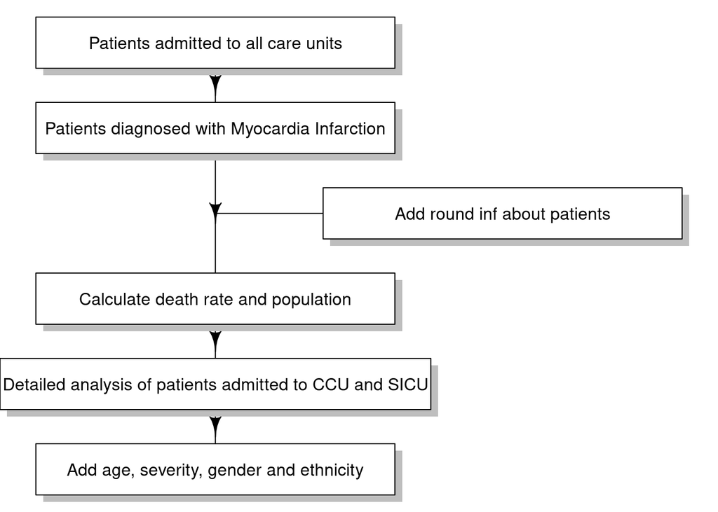

```r
library(shape)
library(diagram)

# set margins and multiplot
par(mfrow = c(1, 1))
par(mar = c(0, 0, 0, 0))

# initialise a plot device
openplotmat()

# position of boxes
# 1st column indicates x axis position between 0 and 1
# 2nd column indicates y axis position between 0 and 1
# automatically assigns vertical position
num_of_boxes <- 6
auto_coords = coordinates(num_of_boxes)
vert_pos = rev(auto_coords[,1])
box_pos <- matrix(nrow = num_of_boxes, ncol = 2, data = 0)
box_pos[1,] = c(0.30, vert_pos[1]) # 1st box
box_pos[2,] = c(0.30, vert_pos[2]) # 2nd box
box_pos[3,] = c(0.70, vert_pos[3]) # 3rd box
box_pos[4,] = c(0.30, vert_pos[4]) # etc...
box_pos[5,] = c(0.30, vert_pos[5])
box_pos[6,] = c(0.30, vert_pos[6])

# content of boxes
box_content <- matrix(nrow = num_of_boxes, ncol = 1, data = 0)
box_content[1] = "Patients admitted to all care units" # 1st box
box_content[2] = "Patients diagnosed with Myocardia Infarction" # 2nd box
box_content[3] = "Add round inf about patients" # 3rd box
box_content[4] = "Calculate death rate and population" # etc...
box_content[5] = "Detailed analysis of patients admitted to CCU and SICU"
box_content[6] = "Add age, severity, gender and ethnicity"


# adjust the size of boxes to fit content
box_x <- c(0.25, 0.25, 0.25, 0.25, 0.30, 0.25, 0.25)
box_y <- c(0.05, 0.05, 0.05, 0.05, 0.05, 0.05, 0.05)

# Draw the arrows
straightarrow(from = box_pos[1,], to = box_pos[2,], lwd = 1)
straightarrow(from = c(box_pos[2,1],box_pos[3,2]), to = box_pos[3,], lwd = 1)
straightarrow(from = box_pos[2,], to = box_pos[4,], lwd = 1)
straightarrow(from = box_pos[4,], to = box_pos[5,], lwd = 1)
straightarrow(from = box_pos[5,], to = box_pos[6,], lwd = 1)

# Draw the boxes
for (i in 1:num_of_boxes) {
  textrect(mid = box_pos[i,], radx = box_x[i], rady = box_y[i],
           lab = box_content[i],
           shadow.col = "grey")
  }
```

In this part, we calculate the death rate in all unit cares to see the difference.

```r
tbl <- as_tibble(data.frame(care_unit = c("ccu", "csru", "micu", "sicu", "tsicu"))) %>%
  mutate(deathrate = c(sum(!is.na(ccu$mortality))/nrow(ccu), sum(!is.na(csru$mortality))/nrow(csru), sum(!is.na(micu$mortality))/nrow(micu), sum(!is.na(sicu$mortality))/nrow(sicu), sum(!is.na(tsicu$mortality))/nrow(tsicu))) %>%
  mutate(population = c(nrow(ccu), nrow(csru), nrow(micu), nrow(sicu), nrow(tsicu))) %>%
  mutate(number_of_death = c(sum(!is.na(ccu$mortality)), sum(!is.na(csru$mortality)), sum(!is.na(micu$mortality)), sum(!is.na(sicu$mortality)), sum(!is.na(tsicu$mortality)))) %>%
  print()
```

```
## # A tibble: 5 x 4
##   care_unit deathrate population number_of_death
##   <fct>         <dbl>      <int>           <int>
## 1 ccu           0.256       1675             429
## 2 csru          0.172        775             133
## 3 micu          0.411        265             109
## 4 sicu          0.461        102              47
## 5 tsicu         0.275         51              14
```

We can see the highest death rate happens in SICU, and highest number of patients were admitted to CCU, so we analyze the detailed information of passed patients transfered to SICU and CCU in the following parts.

## CCU

- Age

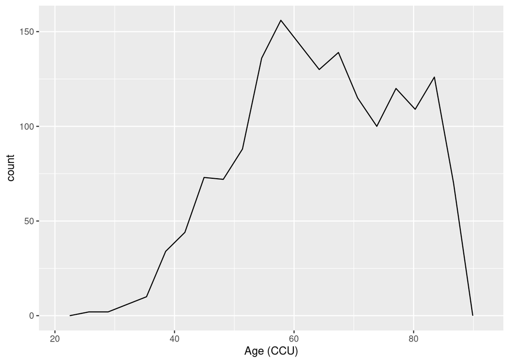

```r
ccu %>%
  ggplot(aes(x = age)) +
  geom_freqpoly(bins = 20) +
  labs(x = "Age (CCU)")
```

Then we consider people who died within 30 days after discharge.

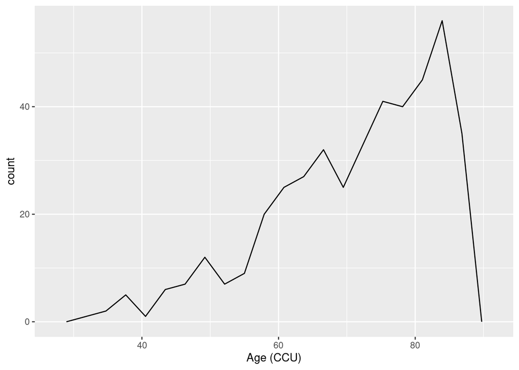

```r
ccu %>%
  filter(mortality == TRUE) %>%
  ggplot(aes(x = age)) +
  geom_freqpoly(bins = 20) +
  labs(x = "Age (CCU)")
```

A better picture is shown below.

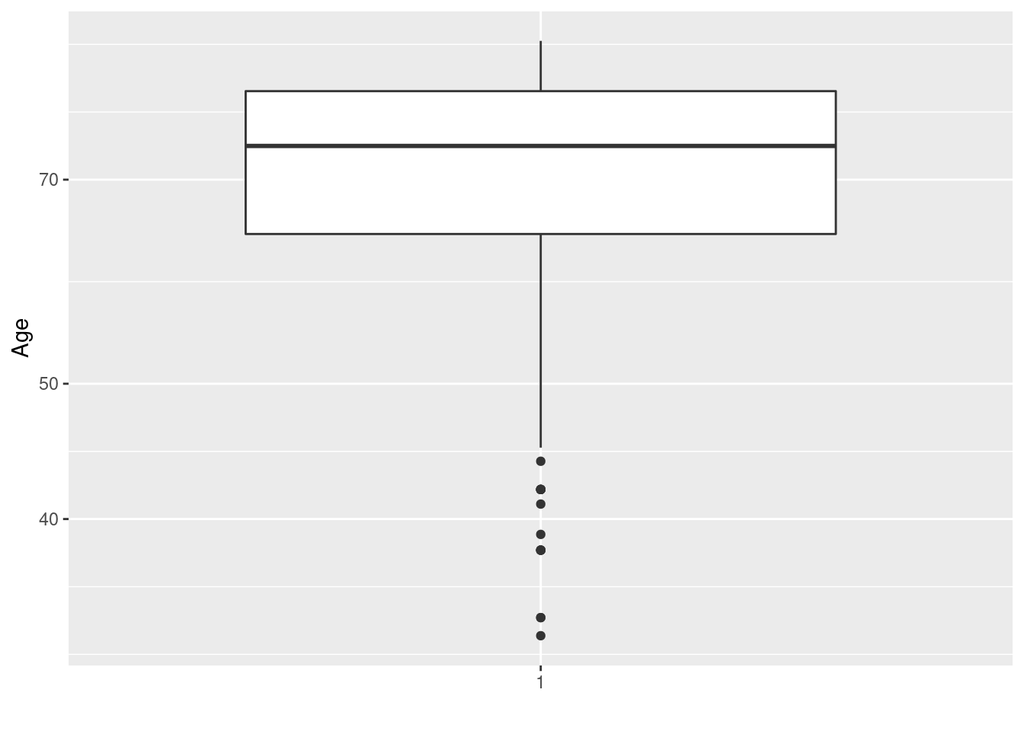

```r
ccu %>%
  filter(mortality == TRUE) %>%
  ggplot() +
  geom_boxplot(mapping = aes(x = factor(1), y = age)) +
  labs(x = "", y = "Age") +
  scale_y_log10()
```

- Severity

In this section, we want to discuss the severity of passed patients’ ailments when they leave the hospital.

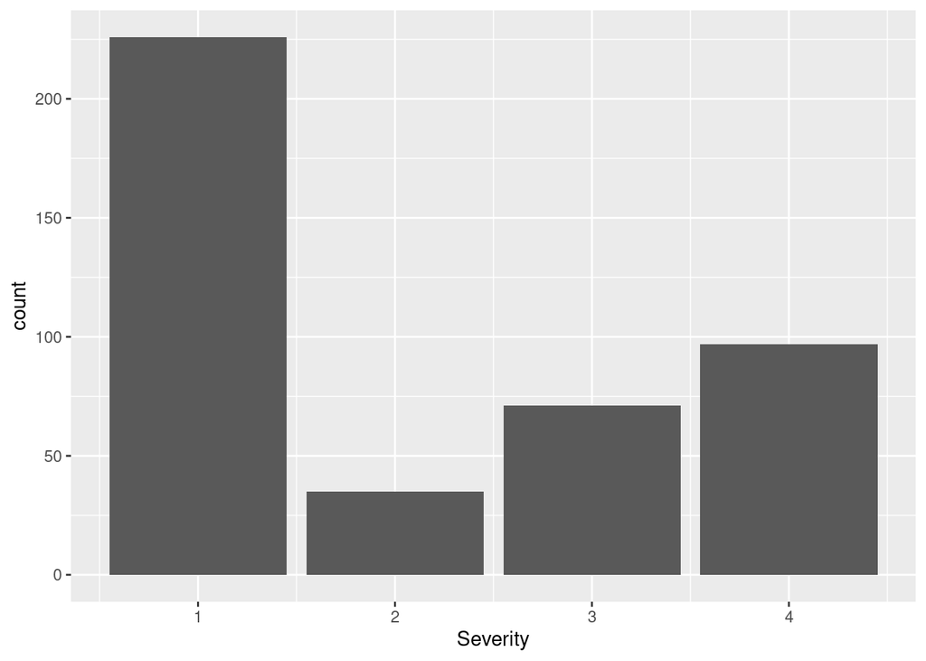

```r
ccu %>%
  filter(mortality == TRUE) %>%
  ggplot() +
  geom_bar(mapping = aes(x = drg_severity)) +
  labs(x = "Severity")
```

We can see that most of the passed patients leave the hospital when their diagnosis are not very severe and less than half of the patients are highly severe.

- Gender

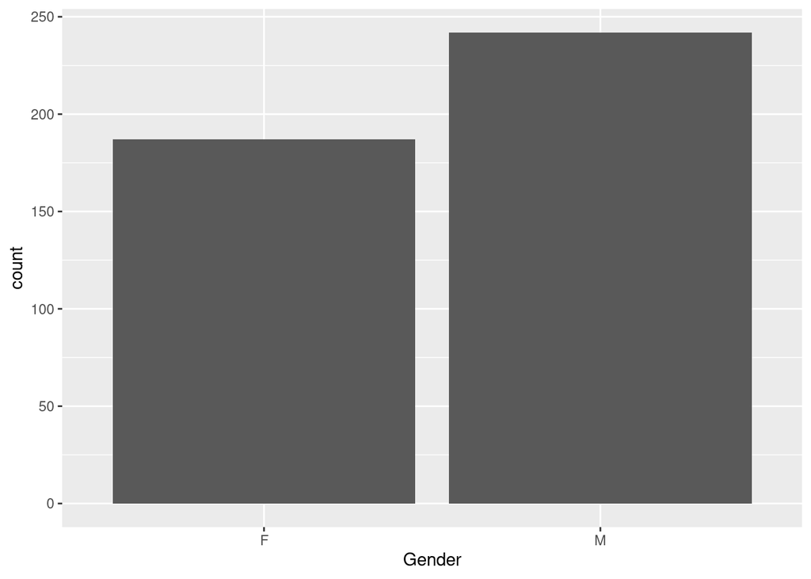

```r
ccu %>%
  filter(mortality == TRUE) %>%
  ggplot() +
  geom_bar(mapping = aes(x = gender)) +
  labs(x = "Gender")
```

In this case, we know that more male patients passed within 30 days, it’s because the number of males patients is larger than that of female patients in the first place.

-Ethnicity

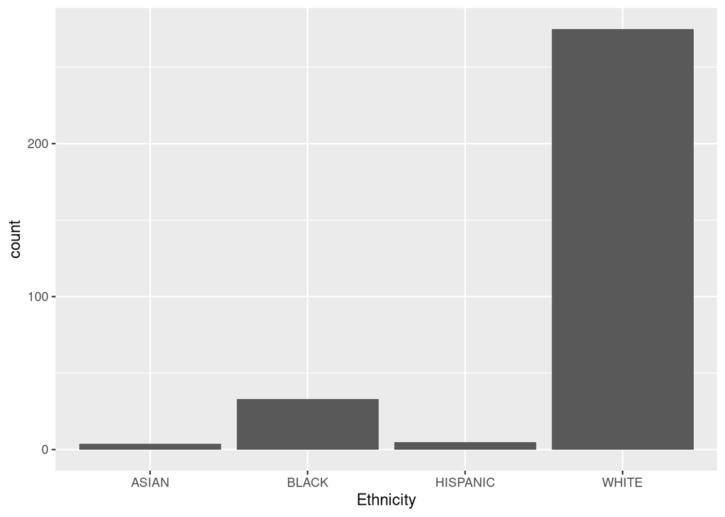

```r
ccu %>%
  filter(mortality == TRUE) %>%
  filter(ethnic_group != "UNKNOWN") %>%
  ggplot() +
  geom_bar(mapping = aes(x = ethnic_group)) +
  labs(x = "Ethnicity")
```

Ignoring the unknown ethnicity, we can see that the majority of passed patients are white, only a few patients are Asian or Hispanic.

## SICU

- Age

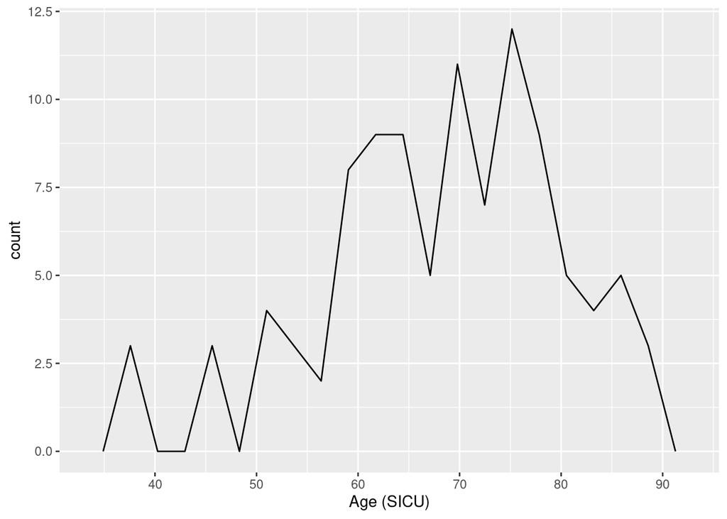

```r
sicu %>%
  ggplot(aes(x = age)) +
  geom_freqpoly(bins = 20) +
  labs(x = "Age (SICU)")
```

As shown in the figure above, the majority of myocardia infarction patients admitted to SICU are between 60 to 80 years old, which makes sence because elderly people may have higher risk in getting heart attack.

Then we consider people who died within 30 days after discharge.

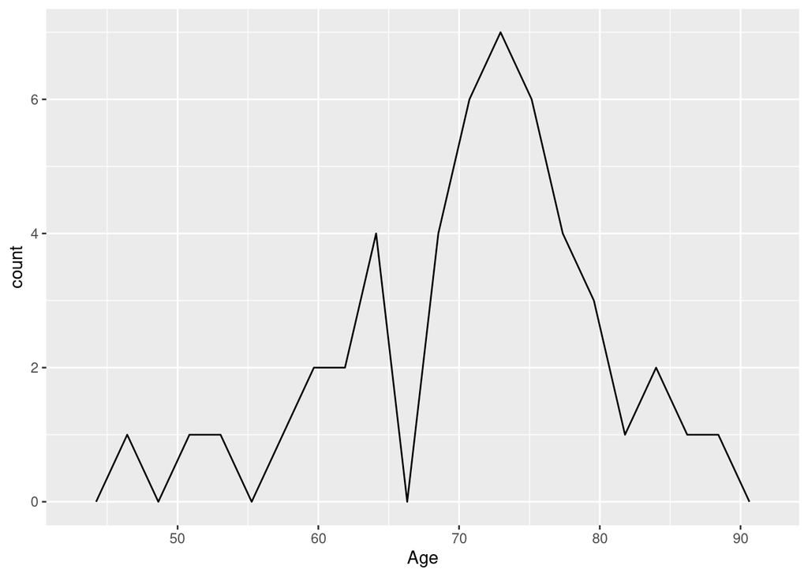

```r
sicu %>%
  filter(mortality == TRUE) %>%
  ggplot(aes(x = age)) +
  geom_freqpoly(bins = 20) +
  labs(x = "Age")
```

A better picture is shown below.

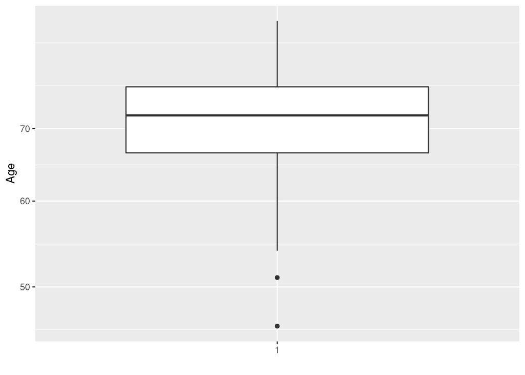

```r
sicu %>%
  filter(mortality == TRUE) %>%
  ggplot() +
  geom_boxplot(mapping = aes(x = factor(1), y = age)) +
  labs(x = "", y = "Age") +
  scale_y_log10()
```

It’s clearly that the majority of myocardia infarction patients admitted to SICU and died within 30 days is about 72 years old.

- Severity

In this section, we want to discuss the severity of passed patients’ ailments when they leave the hospital.

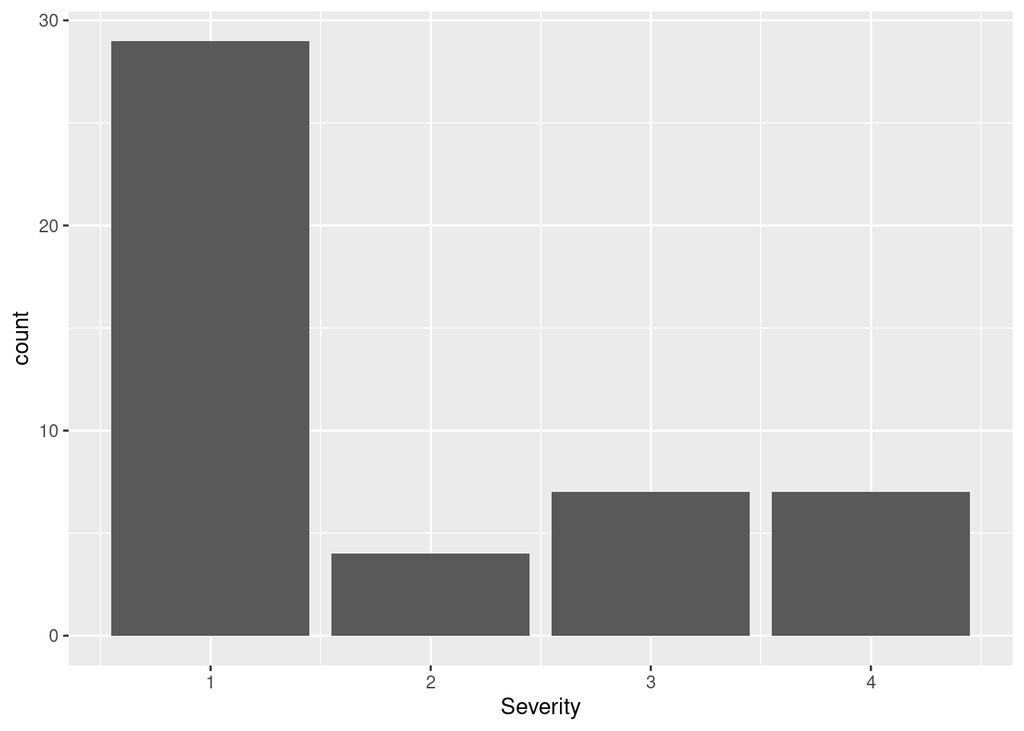

```r
sicu %>%
  filter(mortality == TRUE) %>%
  ggplot() +
  geom_bar(mapping = aes(x = drg_severity)) +
  labs(x = "Severity")
```

We can see that most of the passed patients leave the hospital when their diagnosis are not very severe and less than a quarter of the patients are highly severe.

- Gender

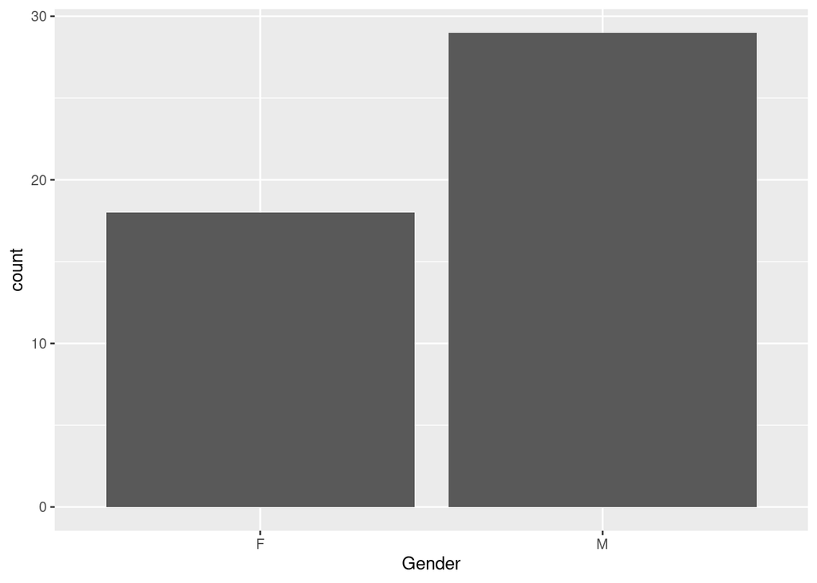

```r
sicu %>%
  filter(mortality == TRUE) %>%
  ggplot() +
  geom_bar(mapping = aes(x = gender)) +
  labs(x = "Gender")
```

In this case, we know that more male patients passed within 30 days, it’s because the number of males patients is larger than that of female patients in the first place.

-Ethnicity

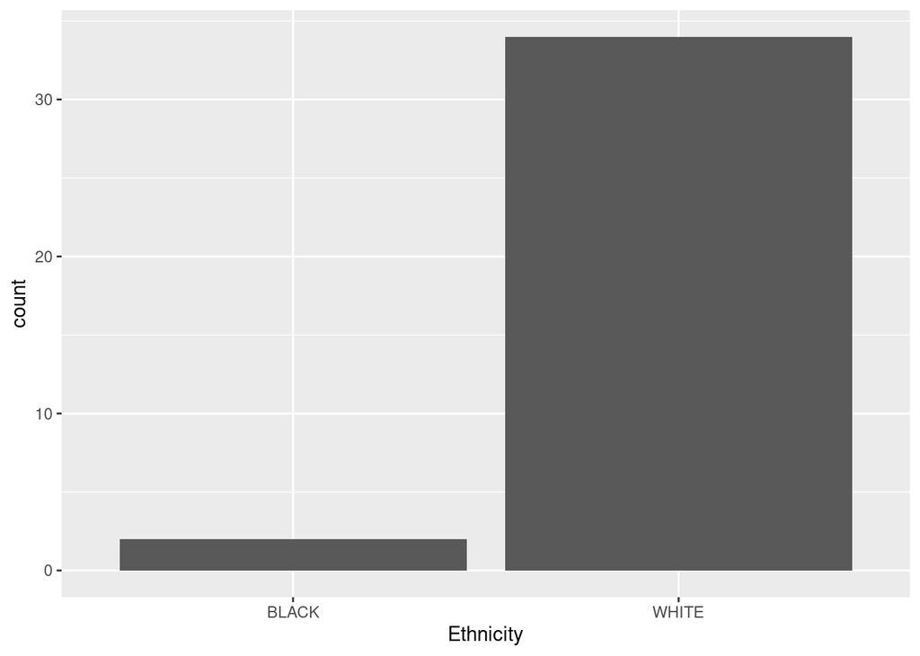

```r
sicu %>%
  filter(mortality == TRUE) %>%
  filter(ethnic_group != "UNKNOWN") %>%
  ggplot() +
  geom_bar(mapping = aes(x = ethnic_group)) +
  labs(x = "Ethnicity")
```

# Analytics

```r
sicu_d <- sicu %>%
  mutate(los = ifelse(mortality,1,0)) %>%
  mutate(principal_dx = ifelse(principal_dx,1,0)) %>%
  mutate(ethnic_group = case_when(
    str_detect(ethnic_group, "ASIAN") ~ 1,
    str_detect(ethnic_group, "BLACK") ~ 2,
    str_detect(ethnic_group, "HISPANIC") ~ 3,
    str_detect(ethnic_group, "WHITE") ~ 4,
    str_detect(ethnic_group, "UNKNOWN") ~ 5
  )) %>%
  select(age, drg_severity, icd9_code, principal_dx, ethnic_group, los) %>%
  mutate(age = age/45.0) %>%
  mutate(drg_severity = drg_severity/4) %>%
  mutate(icd9_code = as.numeric(icd9_code)/68000) %>%
  mutate(ethnic_group = ethnic_group/5) %>%
  print()
```

```
## # A tibble: 102 x 6
##      age drg_severity icd9_code principal_dx ethnic_group   los
##    <dbl>        <dbl>     <dbl>        <dbl>        <dbl> <dbl>
##  1  1.69         0.25   0.604              0          0.8     1
##  2  1.76         0.75   0.604              0          0.8     1
##  3  1.71         0.25   0.604              0          0.8     1
##  4  1.58         0.25   0.00606            0          0.8     1
##  5  1.91         0.25   0.604              1          1       1
##  6  1.2          0.25   0.00606            0          1      NA
##  7  1.56         0.25   0.604              0          1       1
##  8  1.58         0.25   0.604              0          0.8    NA
##  9  1.56         0.25   0.00606            0          0.8     1
## 10  1.73         0.25   0.604              0          0.8     1
## # … with 92 more rows
```

```r
library(keras)
install_keras()
```

```
##
## Installation complete.
```

```r
x_train = sicu_d[1:50,1:5] %>% as.matrix() %>% print()
```

```
##             age drg_severity   icd9_code principal_dx ethnic_group
##  [1,] 1.6888889         0.25 0.604279412            0          0.8
##  [2,] 1.7555556         0.75 0.604279412            0          0.8
##  [3,] 1.7111111         0.25 0.604279412            0          0.8
##  [4,] 1.5777778         0.25 0.006058824            0          0.8
##  [5,] 1.9111111         0.25 0.603544118            1          1.0
##  [6,] 1.2000000         0.25 0.006058824            0          1.0
##  [7,] 1.5555556         0.25 0.604279412            0          1.0
##  [8,] 1.5777778         0.25 0.604279412            0          0.8
##  [9,] 1.5555556         0.25 0.006058824            0          0.8
## [10,] 1.7333333         0.25 0.604279412            0          0.8
## [11,] 1.3777778         0.25 0.006058824            0          0.8
## [12,] 1.4444444         0.25 0.604279412            0          0.8
## [13,] 1.8666667         0.50 0.006058824            0          0.8
## [14,] 1.8666667         0.50 0.006058824            0          0.8
```

[output cut: 36 more lines]

```r
y_train = sicu_d[1:50,6] %>% as.matrix() %>% print()
```

```
##       los
##  [1,]   1
##  [2,]   1
##  [3,]   1
##  [4,]   1
##  [5,]   1
##  [6,]  NA
##  [7,]   1
##  [8,]  NA
##  [9,]   1
## [10,]   1
## [11,]  NA
## [12,]  NA
## [13,]  NA
## [14,]  NA
```

[output cut: 36 more lines]

```r
dim(x_train)
```

```
## [1] 50  5
```

```r
dim(y_train)
```

```
## [1] 50  1
```

```r
x_test = sicu_d[51:102,1:5] %>% as.matrix() %>% print()
```

```
##             age drg_severity   icd9_code principal_dx ethnic_group
##  [1,] 1.7333333         0.25 0.006058824            0          0.8
##  [2,] 0.8222222         0.75 0.603102941            1          0.8
##  [3,] 0.8222222         0.75 0.603102941            1          0.8
##  [4,] 1.9111111         0.50 0.006058824            0          0.8
##  [5,] 1.9111111         0.50 0.006058824            0          0.8
##  [6,] 1.7777778         0.50 0.006058824            0          0.8
##  [7,] 1.7777778         0.50 0.006058824            0          0.8
##  [8,] 1.6000000         1.00 0.602955882            1          0.8
##  [9,] 1.6000000         1.00 0.602955882            1          0.8
## [10,] 1.6888889         0.50 0.006058824            0          0.8
## [11,] 1.6888889         0.50 0.006058824            0          0.8
## [12,] 1.3111111         0.25 0.006058824            0          0.8
## [13,] 1.3111111         0.25 0.006058824            0          0.8
## [14,] 1.4222222         0.75 0.006058824            0          0.8
```

[output cut: 38 more lines]

```r
y_test = sicu_d[51:102,6] %>% as.matrix() %>% print()
```

```
##       los
##  [1,]  NA
##  [2,]  NA
##  [3,]  NA
##  [4,]  NA
##  [5,]  NA
##  [6,]   1
##  [7,]   1
##  [8,]   1
##  [9,]   1
## [10,]  NA
## [11,]  NA
## [12,]   1
## [13,]   1
## [14,]   1
```

[output cut: 38 more lines]

```r
dim(x_test)
```

```
## [1] 52  5
```

```r
dim(y_test)
```

```
## [1] 52  1
```

```r
#model <- keras_model_sequential()
#model %>%
#  layer_dense(units = 1e20, activation = 'relu', input_shape = c(5))
#summary(model)
```

```r
#model %>%
#  compile(
#  loss = 'sparse_categorical_crossentropy',
#  optimizer = optimizer_rmsprop(),
#  metrics = c('accuracy')
#)
```

```r
#system.time({
#  history <- model %>% fit(
#  x_train, y_train,
#  epochs = 30, batch_size = 20,
#  validation_split = 0.2
#)
#})
#plot(history)
```

```r
#model %>% evaluate(x_test, y_test)
```

```r
#model %>% predict_classes(x_test) %>% head()
```

# Conclusions

With the analysis above, we learn that CCU has the largest population of myocardia infarction patients (1675) and 429 of them passed within 30 days after discharge, where the deathrate is 25.61%. The highest deathrate presents itself in case of SICU, i.e., 46.08%. CSRU, MICU, and TSICU have deathrate of 17.16%, 41.13% and 27.45% respectively, while there is no data of myocardia infarction patients admitted to NICU and NWARD. In this assignment, I detailedly analyse the data of CCU and SICU. I find that most of passed patients are about 72 years old. And male patients are more than female patients, but it may because the initial male patients are more than female patients. Also, I find that most of the passed patients are slightly severe when they leave the hospital, which should draw family members’ attention to care of patients after discharge. In the data we study, the marjority of patients are white, which may because the data are collected mainly in white community.